# cluster_penguins

## Exploring the Penguins data set further

```python
import numpy as np
import pandas as pd
import matplotlib.pyplot as plt

import seaborn as sns
```

```python
penguins = sns.load_dataset('penguins')
```

```python
penguins.info()
```

```
<class 'pandas.core.frame.DataFrame'>
RangeIndex: 344 entries, 0 to 343
Data columns (total 7 columns):
 #   Column             Non-Null Count  Dtype
---  ------             --------------  -----
 0   species            344 non-null    object
 1   island             344 non-null    object
 2   bill_length_mm     342 non-null    float64
 3   bill_depth_mm      342 non-null    float64
 4   flipper_length_mm  342 non-null    float64
 5   body_mass_g        342 non-null    float64
 6   sex                333 non-null    object
dtypes: float64(4), object(3)
memory usage: 18.9+ KB
```

```python
penguins.describe()
```

|  | bill_length_mm | bill_depth_mm | flipper_length_mm | body_mass_g |
| --- | --- | --- | --- | --- |
| count | 342.000000 | 342.000000 | 342.000000 | 342.000000 |
| mean | 43.921930 | 17.151170 | 200.915205 | 4201.754386 |
| std | 5.459584 | 1.974793 | 14.061714 | 801.954536 |
| min | 32.100000 | 13.100000 | 172.000000 | 2700.000000 |
| 25% | 39.225000 | 15.600000 | 190.000000 | 3550.000000 |
| 50% | 44.450000 | 17.300000 | 197.000000 | 4050.000000 |
| 75% | 48.500000 | 18.700000 | 213.000000 | 4750.000000 |
| max | 59.600000 | 21.500000 | 231.000000 | 6300.000000 |

Create a histogram for each numeric variable using Pandas default plotting.

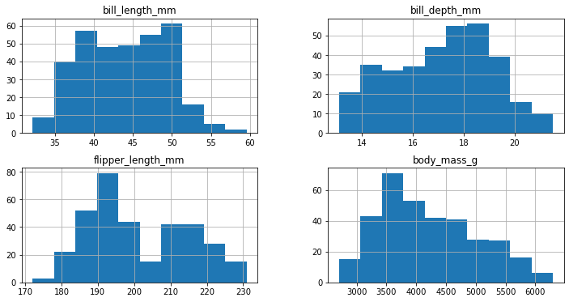

```python
penguins.hist(figsize=(12, 6))

plt.show()
```

Histograms represent the distribution of each variable. But how do the variables relate to each other?

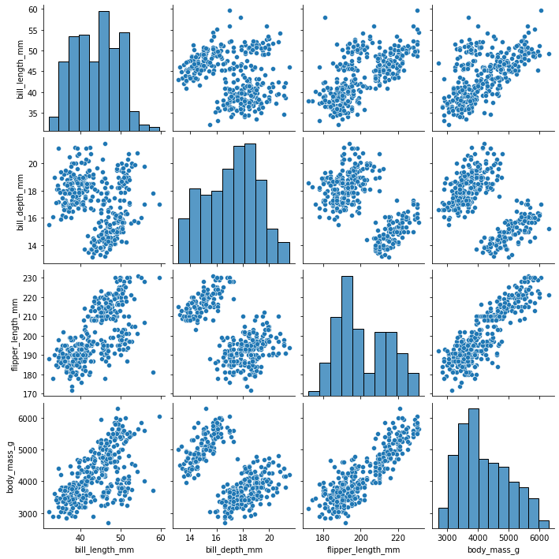

```python
sns.pairplot(data = penguins)
```

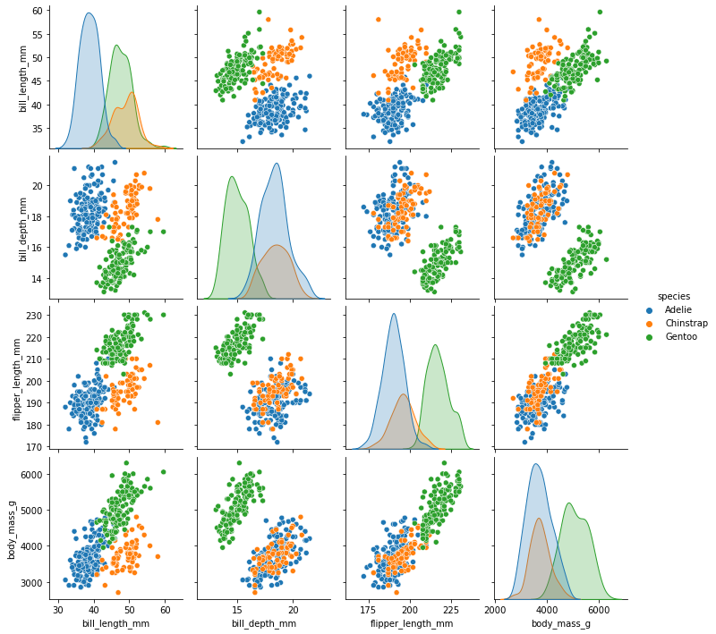

```python
sns.pairplot(data = penguins, hue='species')

plt.show()
```

Let's study the correlation between the variables.

```python
penguins.corr()
```

|  | bill_length_mm | bill_depth_mm | flipper_length_mm | body_mass_g |
| --- | --- | --- | --- | --- |
| bill_length_mm | 1.000000 | -0.235053 | 0.656181 | 0.595110 |
| bill_depth_mm | -0.235053 | 1.000000 | -0.583851 | -0.471916 |
| flipper_length_mm | 0.656181 | -0.583851 | 1.000000 | 0.871202 |
| body_mass_g | 0.595110 | -0.471916 | 0.871202 | 1.000000 |

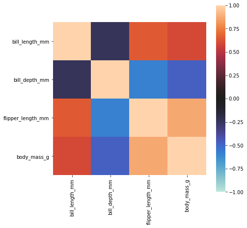

```python
fig, ax = plt.subplots(figsize=(7, 7))

sns.heatmap(penguins.corr(), square=True, vmin=-1, vmax=1, center=0)

plt.show()
```

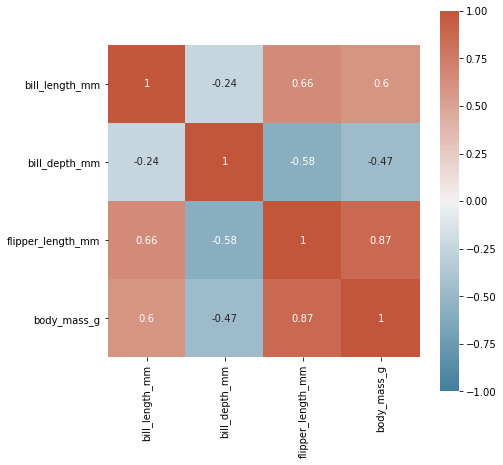

```python
fig, ax = plt.subplots(figsize=(7, 7))

sns.heatmap(penguins.corr(), square=True, vmin=-1, vmax=1, center=0,
           cmap=sns.diverging_palette(230, 20, as_cmap=True),
           annot=True)

plt.show()
```

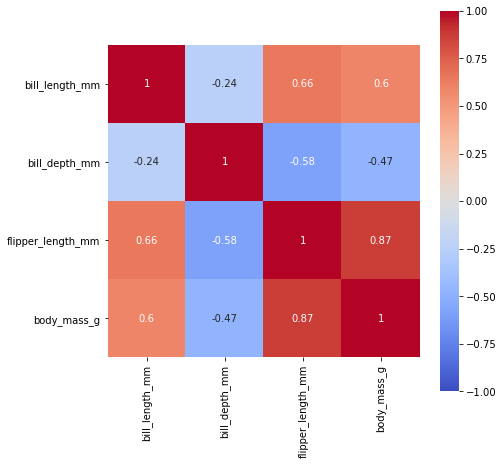

```python
fig, ax = plt.subplots(figsize=(7, 7))

sns.heatmap(penguins.corr(), square=True, vmin=-1, vmax=1, center=0,
           cmap='coolwarm',
           annot=True)

plt.show()
```

```python
penguins.groupby('species').corr()
```

| species |  | bill_length_mm | bill_depth_mm | flipper_length_mm | body_mass_g |
| --- | --- | --- | --- | --- | --- |
| Adelie | bill_length_mm | 1.000000 | 0.391492 | 0.325785 | 0.548866 |
|  | bill_depth_mm | 0.391492 | 1.000000 | 0.307620 | 0.576138 |
|  | flipper_length_mm | 0.325785 | 0.307620 | 1.000000 | 0.468202 |
|  | body_mass_g | 0.548866 | 0.576138 | 0.468202 | 1.000000 |
| Chinstrap | bill_length_mm | 1.000000 | 0.653536 | 0.471607 | 0.513638 |
|  | bill_depth_mm | 0.653536 | 1.000000 | 0.580143 | 0.604498 |
|  | flipper_length_mm | 0.471607 | 0.580143 | 1.000000 | 0.641559 |
|  | body_mass_g | 0.513638 | 0.604498 | 0.641559 | 1.000000 |
| Gentoo | bill_length_mm | 1.000000 | 0.643384 | 0.661162 | 0.669166 |
|  | bill_depth_mm | 0.643384 | 1.000000 | 0.706563 | 0.719085 |
|  | flipper_length_mm | 0.661162 | 0.706563 | 1.000000 | 0.702667 |
|  | body_mass_g | 0.669166 | 0.719085 | 0.702667 | 1.000000 |

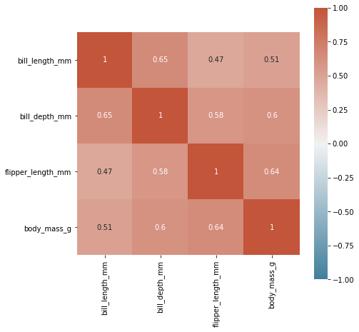

```python
fig, ax = plt.subplots(figsize=(7, 7))

sns.heatmap(penguins.groupby('species').corr().loc['Chinstrap'],
            square=True, vmin=-1, vmax=1, center=0,
           cmap=sns.diverging_palette(230, 20, as_cmap=True),
           annot=True)

plt.show()
```

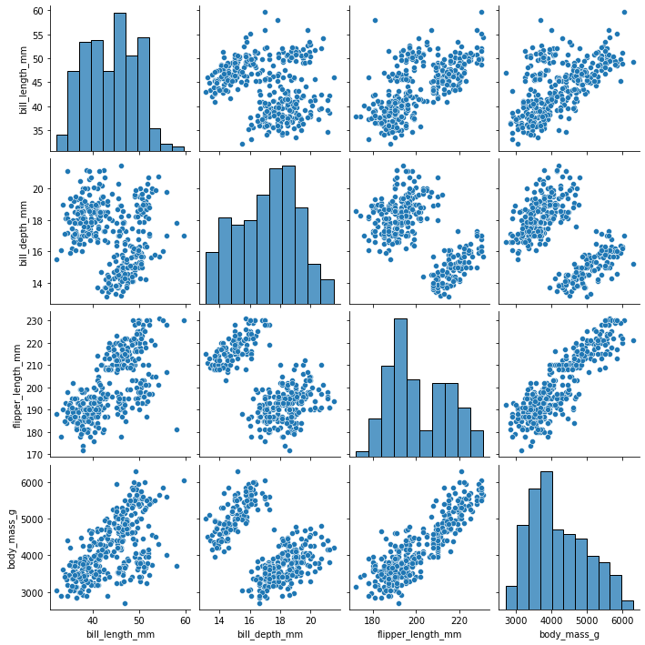

```python
sns.pairplot(penguins)
```

```python
penguins.describe()
```

|  | bill_length_mm | bill_depth_mm | flipper_length_mm | body_mass_g |
| --- | --- | --- | --- | --- |
| count | 342.000000 | 342.000000 | 342.000000 | 342.000000 |
| mean | 43.921930 | 17.151170 | 200.915205 | 4201.754386 |
| std | 5.459584 | 1.974793 | 14.061714 | 801.954536 |
| min | 32.100000 | 13.100000 | 172.000000 | 2700.000000 |
| 25% | 39.225000 | 15.600000 | 190.000000 | 3550.000000 |
| 50% | 44.450000 | 17.300000 | 197.000000 | 4050.000000 |
| 75% | 48.500000 | 18.700000 | 213.000000 | 4750.000000 |
| max | 59.600000 | 21.500000 | 231.000000 | 6300.000000 |

Plot the histograms of the 4 features on one figure.

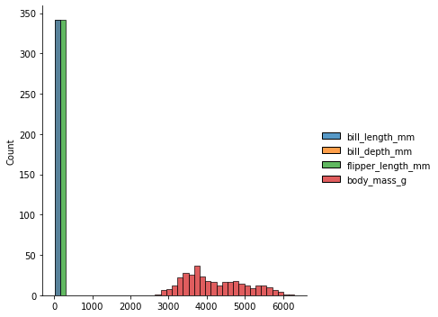

```python
sns.displot(data=penguins)

plt.show()
```

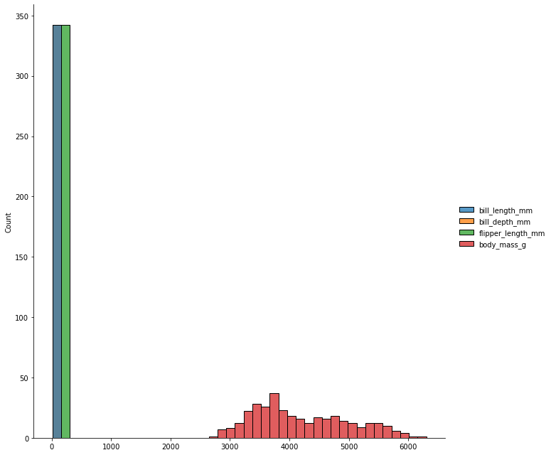

```python
sns.displot(data=penguins, height=9)

plt.show()
```

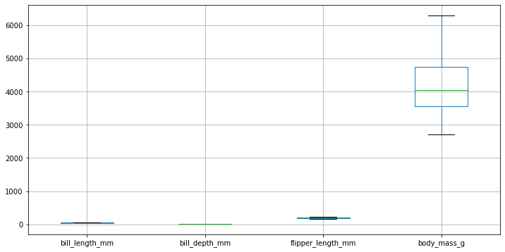

```python
fig, ax = plt.subplots(figsize=(12, 6))

penguins.boxplot(ax=ax)

plt.show()
```

## Standardize the features

Calculate the average and the standard deviation for each variable.

```python
penguins.describe().loc[['mean', 'std']].T.reset_index()
```

|  | index | mean | std |
| --- | --- | --- | --- |
| 0 | bill_length_mm | 43.921930 | 5.459584 |
| 1 | bill_depth_mm | 17.151170 | 1.974793 |
| 2 | flipper_length_mm | 200.915205 | 14.061714 |
| 3 | body_mass_g | 4201.754386 | 801.954536 |

Use scikit-learn to transform the features from their original scale to their STANDARDIZED scale.

We will use the `StandardScaler()` function to perform this transformation for us.

```python
from sklearn.preprocessing import StandardScaler
```

Perform the transformation following the scikit-learn "conventions" of "FIT" then "TRANSFORM"/"PREDICT".

```python
# initialize the object

pens_standardize = StandardScaler()
```

```python
%whos
```

```
Variable           Type              Data/Info
----------------------------------------------
StandardScaler     type              <class 'sklearn.preproces<...>ng._data.StandardScaler'>
ax                 AxesSubplot       AxesSubplot(0.125,0.1925;0.62x0.62)
fig                Figure            Figure(504x504)
np                 module            <module 'numpy' from 'C:\<...>ges\\numpy\\__init__.py'>
pd                 module            <module 'pandas' from 'C:<...>es\\pandas\\__init__.py'>
penguins           DataFrame             species     island  b<...>n\n[344 rows x 7 columns]
pens_standardize   StandardScaler    StandardScaler()
plt                module            <module 'matplotlib.pyplo<...>\\matplotlib\\pyplot.py'>
sns                module            <module 'seaborn' from 'C<...>s\\seaborn\\__init__.py'>
```

"FIT" the standardization object.

```python
# first, separate out the numeric features or variables from the larger dataset
pens_features = penguins.select_dtypes('number').copy()
```

```python
pens_features.info()
```

```
<class 'pandas.core.frame.DataFrame'>
RangeIndex: 344 entries, 0 to 343
Data columns (total 4 columns):
 #   Column             Non-Null Count  Dtype
---  ------             --------------  -----
 0   bill_length_mm     342 non-null    float64
 1   bill_depth_mm      342 non-null    float64
 2   flipper_length_mm  342 non-null    float64
 3   body_mass_g        342 non-null    float64
dtypes: float64(4)
memory usage: 10.9 KB
```

```python
pens_standardize.fit(pens_features)
```

```
StandardScaler()
```

```python
%whos
```

```
Variable           Type              Data/Info
----------------------------------------------
StandardScaler     type              <class 'sklearn.preproces<...>ng._data.StandardScaler'>
ax                 AxesSubplot       AxesSubplot(0.125,0.125;0.775x0.755)
fig                Figure            Figure(864x432)
np                 module            <module 'numpy' from 'C:\<...>ges\\numpy\\__init__.py'>
pd                 module            <module 'pandas' from 'C:<...>es\\pandas\\__init__.py'>
penguins           DataFrame             species     island  b<...>n\n[344 rows x 7 columns]
pens_features      DataFrame              bill_length_mm  bill<...>n\n[344 rows x 4 columns]
pens_standardize   StandardScaler    StandardScaler()
plt                module            <module 'matplotlib.pyplo<...>\\matplotlib\\pyplot.py'>
sns                module            <module 'seaborn' from 'C<...>s\\seaborn\\__init__.py'>
```

"Apply" the standardizing function, which is scikit-learn nomenclature is "TRANSFORM" using the `.transform()` method.

```python
Xpens = pens_standardize.transform(pens_features)
```

```python
print( type(Xpens) )
```

```
<class 'numpy.ndarray'>
```

```python
Xpens.shape
```

```
(344, 4)
```

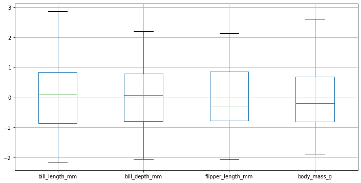

```python
fig, ax = plt.subplots(figsize=(12, 6))

pd.DataFrame(Xpens, columns=pens_features.columns).boxplot(ax=ax)

plt.show()
```

Look at the distributions, and this time use the density or 'kde' plot from Seaborn.

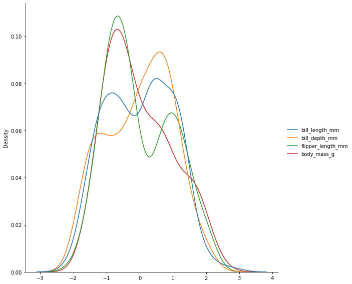

```python
sns.displot(data = pd.DataFrame(Xpens, columns=pens_features.columns),
           kind='kde',
           height=8)

plt.show()
```

## KMeans

Import in the KMeans function from scikit-learn.

```python
from sklearn.cluster import KMeans
```

Start out with 2 clusters.

First, initialize the object.

Second, fit the object to a data set to create a MODEL.

Third, apply the MODEL (object) to a data set.

In the context of KMeans, "applying" is known as "PREDICTING" where we "PREDICT" the cluster labels.

```python
# intiialize the object
km2 = KMeans(n_clusters=2, random_state=121, n_init=25, max_iter=500)
```

```python
%whos
```

```
Variable           Type              Data/Info
----------------------------------------------
KMeans             type              <class 'sklearn.cluster._kmeans.KMeans'>
StandardScaler     type              <class 'sklearn.preproces<...>ng._data.StandardScaler'>
Xpens              ndarray           344x4: 1376 elems, type `float64`, 11008 bytes
ax                 AxesSubplot       AxesSubplot(0.125,0.125;0.775x0.755)
fig                Figure            Figure(864x432)
km2                KMeans            KMeans(max_iter=500, n_cl<...>nit=25, random_state=121)
np                 module            <module 'numpy' from 'C:\<...>ges\\numpy\\__init__.py'>
pd                 module            <module 'pandas' from 'C:<...>es\\pandas\\__init__.py'>
penguins           DataFrame             species     island  b<...>n\n[344 rows x 7 columns]
pens_features      DataFrame              bill_length_mm  bill<...>n\n[344 rows x 4 columns]
pens_standardize   StandardScaler    StandardScaler()
plt                module            <module 'matplotlib.pyplo<...>\\matplotlib\\pyplot.py'>
sns                module            <module 'seaborn' from 'C<...>s\\seaborn\\__init__.py'>
```

```python
km2.fit(Xpens)
```

[output not shown]

```python
penguins.info()
```

```
<class 'pandas.core.frame.DataFrame'>
RangeIndex: 344 entries, 0 to 343
Data columns (total 7 columns):
 #   Column             Non-Null Count  Dtype
---  ------             --------------  -----
 0   species            344 non-null    object
 1   island             344 non-null    object
 2   bill_length_mm     342 non-null    float64
 3   bill_depth_mm      342 non-null    float64
 4   flipper_length_mm  342 non-null    float64
 5   body_mass_g        342 non-null    float64
 6   sex                333 non-null    object
dtypes: float64(4), object(3)
memory usage: 18.9+ KB
```

```python
penguins.head(20)
```

|  | species | island | bill_length_mm | bill_depth_mm | flipper_length_mm | body_mass_g | sex |
| --- | --- | --- | --- | --- | --- | --- | --- |
| 0 | Adelie | Torgersen | 39.1 | 18.7 | 181.0 | 3750.0 | Male |
| 1 | Adelie | Torgersen | 39.5 | 17.4 | 186.0 | 3800.0 | Female |
| 2 | Adelie | Torgersen | 40.3 | 18.0 | 195.0 | 3250.0 | Female |
| 3 | Adelie | Torgersen | NaN | NaN | NaN | NaN | NaN |
| 4 | Adelie | Torgersen | 36.7 | 19.3 | 193.0 | 3450.0 | Female |
| 5 | Adelie | Torgersen | 39.3 | 20.6 | 190.0 | 3650.0 | Male |
| 6 | Adelie | Torgersen | 38.9 | 17.8 | 181.0 | 3625.0 | Female |
| 7 | Adelie | Torgersen | 39.2 | 19.6 | 195.0 | 4675.0 | Male |
| 8 | Adelie | Torgersen | 34.1 | 18.1 | 193.0 | 3475.0 | NaN |
| 9 | Adelie | Torgersen | 42.0 | 20.2 | 190.0 | 4250.0 | NaN |
| 10 | Adelie | Torgersen | 37.8 | 17.1 | 186.0 | 3300.0 | NaN |
| 11 | Adelie | Torgersen | 37.8 | 17.3 | 180.0 | 3700.0 | NaN |
| 12 | Adelie | Torgersen | 41.1 | 17.6 | 182.0 | 3200.0 | Female |
| 13 | Adelie | Torgersen | 38.6 | 21.2 | 191.0 | 3800.0 | Male |
| 14 | Adelie | Torgersen | 34.6 | 21.1 | 198.0 | 4400.0 | Male |
| 15 | Adelie | Torgersen | 36.6 | 17.8 | 185.0 | 3700.0 | Female |
| 16 | Adelie | Torgersen | 38.7 | 19.0 | 195.0 | 3450.0 | Female |
| 17 | Adelie | Torgersen | 42.5 | 20.7 | 197.0 | 4500.0 | Male |
| 18 | Adelie | Torgersen | 34.4 | 18.4 | 184.0 | 3325.0 | Female |
| 19 | Adelie | Torgersen | 46.0 | 21.5 | 194.0 | 4200.0 | Male |

```python
pens_features.info()
```

```
<class 'pandas.core.frame.DataFrame'>
RangeIndex: 344 entries, 0 to 343
Data columns (total 4 columns):
 #   Column             Non-Null Count  Dtype
---  ------             --------------  -----
 0   bill_length_mm     342 non-null    float64
 1   bill_depth_mm      342 non-null    float64
 2   flipper_length_mm  342 non-null    float64
 3   body_mass_g        342 non-null    float64
dtypes: float64(4)
memory usage: 10.9 KB
```

Drop the missings from the orginal large data set that contains the object types as well.

How many missings in the data set?

```python
penguins.isna()
```

|  | species | island | bill_length_mm | bill_depth_mm | flipper_length_mm | body_mass_g | sex |
| --- | --- | --- | --- | --- | --- | --- | --- |
| 0 | False | False | False | False | False | False | False |
| 1 | False | False | False | False | False | False | False |
| 2 | False | False | False | False | False | False | False |
| 3 | False | False | True | True | True | True | True |
| 4 | False | False | False | False | False | False | False |
| ... | ... | ... | ... | ... | ... | ... | ... |
| 339 | False | False | True | True | True | True | True |
| 340 | False | False | False | False | False | False | False |
| 341 | False | False | False | False | False | False | False |
| 342 | False | False | False | False | False | False | False |
| 343 | False | False | False | False | False | False | False |

344 rows × 7 columns

```python
penguins.isna().sum()
```

```
species               0
island                0
bill_length_mm        2
bill_depth_mm         2
flipper_length_mm     2
body_mass_g           2
sex                  11
dtype: int64
```

Simply drop all rows that have missing values.

```python
penguins_clean = penguins.dropna().copy()
```

```python
penguins_clean.info()
```

```
<class 'pandas.core.frame.DataFrame'>
Int64Index: 333 entries, 0 to 343
Data columns (total 7 columns):
 #   Column             Non-Null Count  Dtype
---  ------             --------------  -----
 0   species            333 non-null    object
 1   island             333 non-null    object
 2   bill_length_mm     333 non-null    float64
 3   bill_depth_mm      333 non-null    float64
 4   flipper_length_mm  333 non-null    float64
 5   body_mass_g        333 non-null    float64
 6   sex                333 non-null    object
dtypes: float64(4), object(3)
memory usage: 20.8+ KB
```

```python
penguins_clean.isna().sum()
```

```
species              0
island               0
bill_length_mm       0
bill_depth_mm        0
flipper_length_mm    0
body_mass_g          0
sex                  0
dtype: int64
```

Select the numeric variables from the clean data set.

```python
pens_features_clean = penguins_clean.select_dtypes('number').copy()
```

We can perform the standardization using a "short-cut" approach wiht the `.fit_transform()`.

```python
X = StandardScaler().fit_transform(pens_features_clean)
```

```python
print( type(X) )

print( X.shape )
```

```
<class 'numpy.ndarray'>
(333, 4)
```

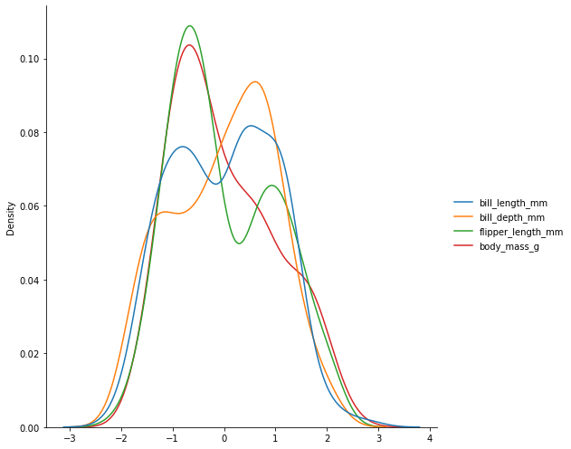

```python
sns.displot(data = pd.DataFrame(X, columns=pens_features_clean.columns),
           kind='kde', height=7)

plt.show()
```

Perform KMeans clustering using the "short-cut" approach. There's an analogous `.fit_predict()`.

```python
clusters_2 = KMeans(n_clusters=2, random_state=121, n_init=25, max_iter=500).fit_predict(X)
```

```python
print( type(clusters_2) )
```

```
<class 'numpy.ndarray'>
```

```python
clusters_2.shape
```

```
(333,)
```

```python
clusters_2[:11]
```

```
array([1, 1, 1, 1, 1, 1, 1, 1, 1, 1, 1])
```

```python
np.unique(clusters_2)
```

```
array([0, 1])
```

Plot the results in matplotlib.

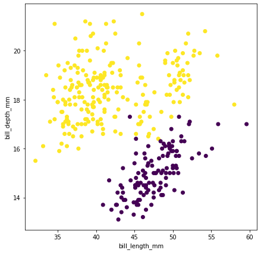

```python
fig, ax = plt.subplots(figsize=(7, 7))

ax.scatter(x = pens_features_clean.bill_length_mm,
          y = pens_features_clean.bill_depth_mm,
          c = clusters_2)

ax.set_xlabel('bill_length_mm')
ax.set_ylabel('bill_depth_mm')

plt.show()
```

Add the `clusters_2` variable into the `penguins_clean` DataFrame.

```python
penguins_clean['k2'] = pd.Series(clusters_2, index=penguins_clean.index)
```

```python
penguins_clean.info()
```

```
<class 'pandas.core.frame.DataFrame'>
Int64Index: 333 entries, 0 to 343
Data columns (total 8 columns):
 #   Column             Non-Null Count  Dtype
---  ------             --------------  -----
 0   species            333 non-null    object
 1   island             333 non-null    object
 2   bill_length_mm     333 non-null    float64
 3   bill_depth_mm      333 non-null    float64
 4   flipper_length_mm  333 non-null    float64
 5   body_mass_g        333 non-null    float64
 6   sex                333 non-null    object
 7   k2                 333 non-null    int32
dtypes: float64(4), int32(1), object(3)
memory usage: 22.1+ KB
```

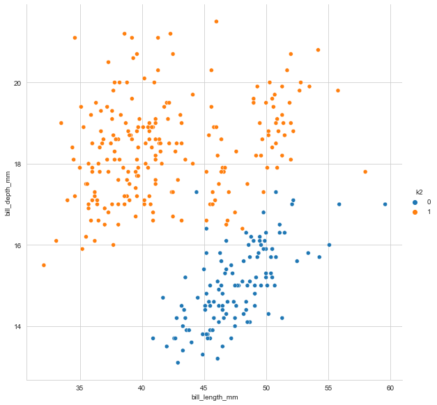

```python
sns.set_style('whitegrid')

sns.relplot(data = penguins_clean,
           x='bill_length_mm',
           y='bill_depth_mm',
           hue='k2',
           kind='scatter',
           height=8)

plt.show()
```

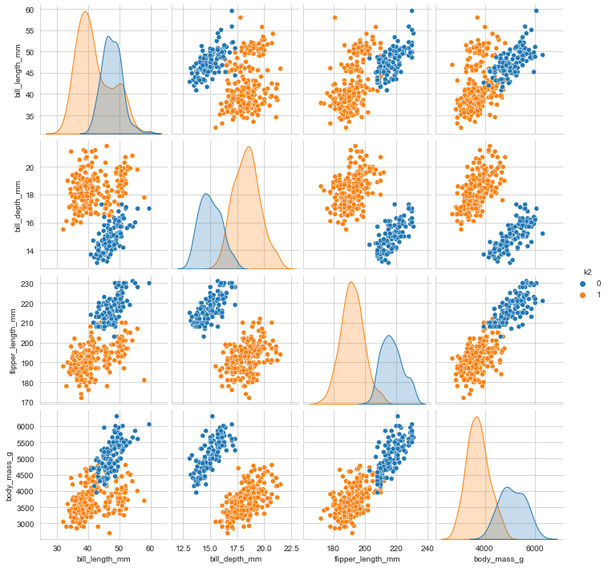

```python
sns.pairplot(data=penguins_clean, hue='k2')

plt.show()
```

What about 3 clusters?

```python
clusters_3 = KMeans(n_clusters=3, random_state=121, n_init=25, max_iter=500).fit_predict(X)
```

```python
np.unique(clusters_3)
```

```
array([0, 1, 2])
```

```python
penguins_clean['k3'] = pd.Series(clusters_3, index=penguins_clean.index)
```

```python
penguins_clean.info()
```

```
<class 'pandas.core.frame.DataFrame'>
Int64Index: 333 entries, 0 to 343
Data columns (total 9 columns):
 #   Column             Non-Null Count  Dtype
---  ------             --------------  -----
 0   species            333 non-null    object
 1   island             333 non-null    object
 2   bill_length_mm     333 non-null    float64
 3   bill_depth_mm      333 non-null    float64
 4   flipper_length_mm  333 non-null    float64
 5   body_mass_g        333 non-null    float64
 6   sex                333 non-null    object
 7   k2                 333 non-null    int32
 8   k3                 333 non-null    int32
dtypes: float64(4), int32(2), object(3)
memory usage: 23.4+ KB
```

```python
penguins_clean.k2 = penguins_clean.k2.astype('category')

penguins_clean.k3 = penguins_clean.k3.astype('category')
```

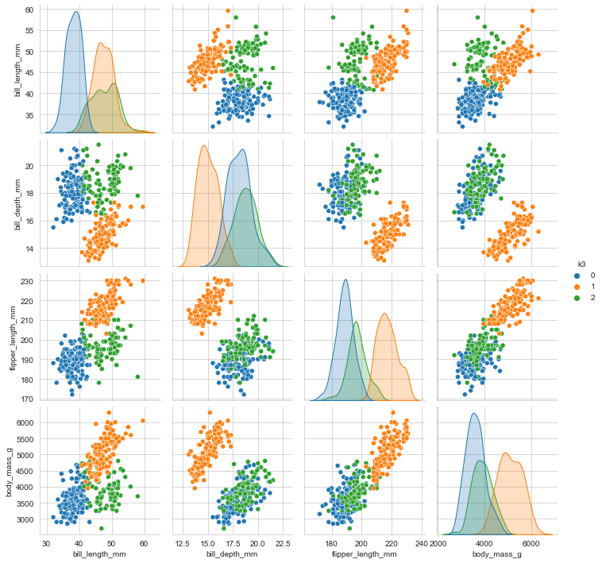

```python
sns.pairplot(data = penguins_clean,
             vars=pens_features_clean.columns,
             hue='k3')

plt.show()
```